# Comparando mecanismos para jukeboxes sociais

*Dados utilizados na pesquisa:*

```r
dados = read_csv(here::here("data/satisfacoes.csv"),
                 col_types = "cdcc")

dados = dados %>%
    filter(scenario != "like/dislike")

glimpse(dados)
```

```
## Rows: 92
## Columns: 4
## $ user_id      <chr> "1", "2", "3", "4", "5", "6", "7", "8", "9", "10", "11", ~
## $ satisfaction <dbl> 2.0, 3.0, 1.5, 1.0, 2.0, 2.5, 2.0, 3.0, 2.0, 2.0, 2.0, 2.~
## $ scenario     <chr> "baseline", "baseline", "baseline", "baseline", "baseline~
## $ group        <chr> "3", "1", "2", "2", "1", "1", "3", "3", "2", "1", "3", "2~
```

### Qual o tamanho do efeito de cada uma das alternativas do sistema comparada com o baseline? Esse efeito é relevante? Vale à pena para um desenvolvedor implementar alguma delas? Qual/quais?

```r
dados_wide = dados %>%
    pivot_wider(names_from = "scenario", values_from = satisfaction)

dados_wide = dados_wide %>%
    mutate(
        skip_baseline = skip - baseline,
        updown_baseline = `up/downvoting` - baseline,
        combined_baseline = combined - baseline

    )
```

```r
theta <- function(d, i) {
    d[i] %>%
        mean(na.rm = T)
}
```

```r
ci_skip = boot(data = dados_wide$skip_baseline,
                   statistic = theta,
                   R = 2000) %>%
    tidy(conf.level = .95,
         conf.method = "bca",
         conf.int = TRUE)
ci_skip
```

```
## # A tibble: 1 x 5
##   statistic     bias std.error conf.low conf.high
##       <dbl>    <dbl>     <dbl>    <dbl>     <dbl>
## 1     0.425 -0.00130     0.132    0.147      0.65
```

```r
ci_updown = boot(data = dados_wide$updown_baseline,
                   statistic = theta,
                   R = 2000) %>%
    tidy(conf.level = .95,
         conf.method = "bca",
         conf.int = TRUE)

ci_updown
```

```
## # A tibble: 1 x 5
##   statistic    bias std.error conf.low conf.high
##       <dbl>   <dbl>     <dbl>    <dbl>     <dbl>
## 1      2.25 0.00377     0.182     1.88      2.59
```

```r
ci_combined = boot(data = dados_wide$combined_baseline,
                   statistic = theta,
                   R = 2000) %>%
    tidy(conf.level = .95,
         conf.method = "bca",
         conf.int = TRUE)

ci_combined
```

```
## # A tibble: 1 x 5
##   statistic      bias std.error conf.low conf.high
##       <dbl>     <dbl>     <dbl>    <dbl>     <dbl>
## 1      1.95 -0.000729     0.216     1.56      2.42
```

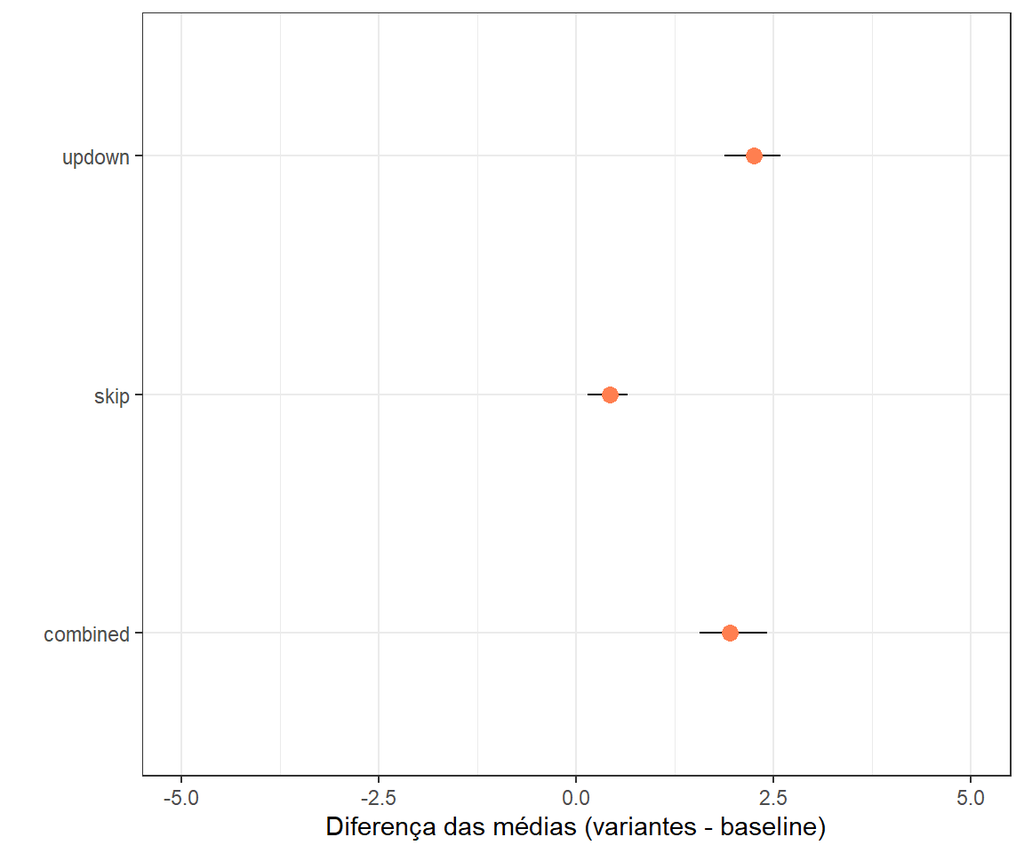

```r
cis = bind_rows(
  "skip" = ci_skip,
  "updown" = ci_updown,
  "combined" = ci_combined,
  .id = "grupo"
)

cis %>%
  ggplot(aes(
            ymin = conf.low,
            y = statistic,
            ymax = conf.high,
            x = grupo
        )) +
        geom_linerange() +
        geom_point(color = "coral", size = 3) +
        scale_y_continuous(limits = c(-5, 5)) +
        labs(x = "", y = "Diferença das médias (variantes - baseline)") +
        coord_flip()
```

**Para o up/downvoting a diferença das médias foi de 2.25 com variação entre 1.88 e 2.59, apresentando um efeito relevante entre médio e alto. Para o skip a diferença das médias foi de 0.42, com variação entre 0.13 e 0.64, apresentando um efeito provavelmente pouco relevante. Já para o combined a diferença das médias foi de 1.95, com variação entre 1.56 e 2.42, apresentando um efeito relevante de médio à alto. Considerando a variação da diferença das médias das alternativas do sistema, é provavel que para um desenvolvedor valha a pena implementar o up/downvoting ou o combined, visto que possuem intervalos de variação semelhantes e com efeitos mais relevantes do que o skip se comparados ao baseline.**

### Qual o tamanho do efeito da combinação de alternativas (a combined) em relação às alternativas separadas?

```r
dados_wide = dados_wide %>%
    mutate(
        skip_combined = skip - combined,
        updown_combined = `up/downvoting` - combined,
        baseline_combined = baseline - combined

    )
```

```r
theta <- function(d, i) {
    d[i] %>%
        mean(na.rm = T)
}
```

```r
ci_skip_combined = boot(data = dados_wide$skip_combined,
                   statistic = theta,
                   R = 2000) %>%
    tidy(conf.level = .95,
         conf.method = "bca",
         conf.int = TRUE)

ci_skip_combined
```

```
## # A tibble: 1 x 5
##   statistic     bias std.error conf.low conf.high
##       <dbl>    <dbl>     <dbl>    <dbl>     <dbl>
## 1     -1.52 -0.00134     0.171    -1.89     -1.21
```

```r
ci_updown_combined = boot(data = dados_wide$updown_combined,
                   statistic = theta,
                   R = 2000) %>%
    tidy(conf.level = .95,
         conf.method = "bca",
         conf.int = TRUE)

ci_updown_combined
```

```
## # A tibble: 1 x 5
##   statistic      bias std.error conf.low conf.high
##       <dbl>     <dbl>     <dbl>    <dbl>     <dbl>
## 1     0.348 -0.000186     0.155   0.0474     0.651
```

```r
ci_baseline_combined = boot(data = dados_wide$baseline_combined,
                   statistic = theta,
                   R = 2000) %>%
    tidy(conf.level = .95,
         conf.method = "bca",
         conf.int = TRUE)

ci_baseline_combined
```

```
## # A tibble: 1 x 5
##   statistic     bias std.error conf.low conf.high
##       <dbl>    <dbl>     <dbl>    <dbl>     <dbl>
## 1     -1.95 0.000394     0.221    -2.44     -1.54
```

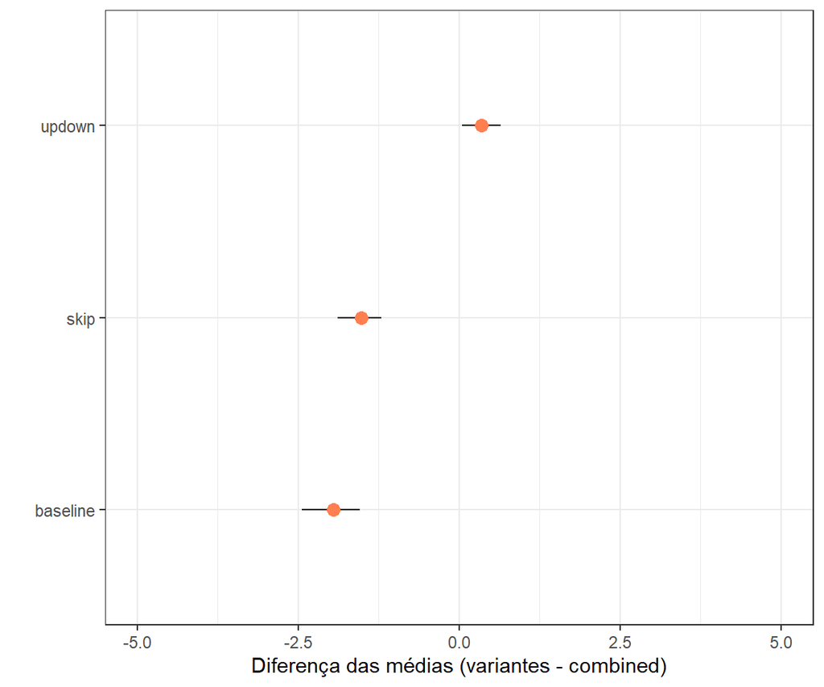

```r
cis = bind_rows(
  "skip" = ci_skip_combined ,
  "updown" = ci_updown_combined ,
  "baseline" = ci_baseline_combined,
  .id = "grupo"
)

cis %>%
  ggplot(aes(
            ymin = conf.low,
            y = statistic,
            ymax = conf.high,
            x = grupo
        )) +
        geom_linerange() +
        geom_point(color = "coral", size = 3) +
        scale_y_continuous(limits = c(-5, 5)) +
        labs(x = "", y = "Diferença das médias (variantes - combined)") +
        coord_flip()
```

**Para o skip a diferença das médias foi de -1.52 com variação entre -1.89 e -1.20, apresentando um efeito relevante entre médio e relativamente alto. Para o up/downvoting a diferença das médias foi de 0.34, com variação entre 0.04 e 0.66, apresentando um efeito baixo provavelmente pouco relevante. Já para o baseline a diferença das médias foi de -1.95, com variação entre -2.42 e -1.58, apresentando um efeito relevante de médio à alto. Considerando a variação da diferença das médias das alternativas separadas e da combinação delas, a combinação das alternativas teve um efeito de médio à alto relevante em relação ao skip e ao baseline, já em relação ao up/downvoting não foi possível observar efeito relevante.**

### Considerando a escolha entre skip e up/downvoting, você recomendaria a alguém interessado em aumentar a satisfação de usuários que prefira a implementação de um deles?

```r
dados_wide = dados_wide %>%
    mutate(
        skip_updown = `up/downvoting` - skip
    )
```

```r
theta <- function(d, i) {
    d[i] %>%
        mean(na.rm = T)
}
```

```r
ci_skip_updown = boot(data = dados_wide$skip_updown,
                   statistic = theta,
                   R = 2000) %>%
    tidy(conf.level = .95,
         conf.method = "bca",
         conf.int = TRUE)

ci_skip_updown
```

```
## # A tibble: 1 x 5
##   statistic     bias std.error conf.low conf.high
##       <dbl>    <dbl>     <dbl>    <dbl>     <dbl>
## 1      1.87 -0.00429     0.135     1.62      2.16
```

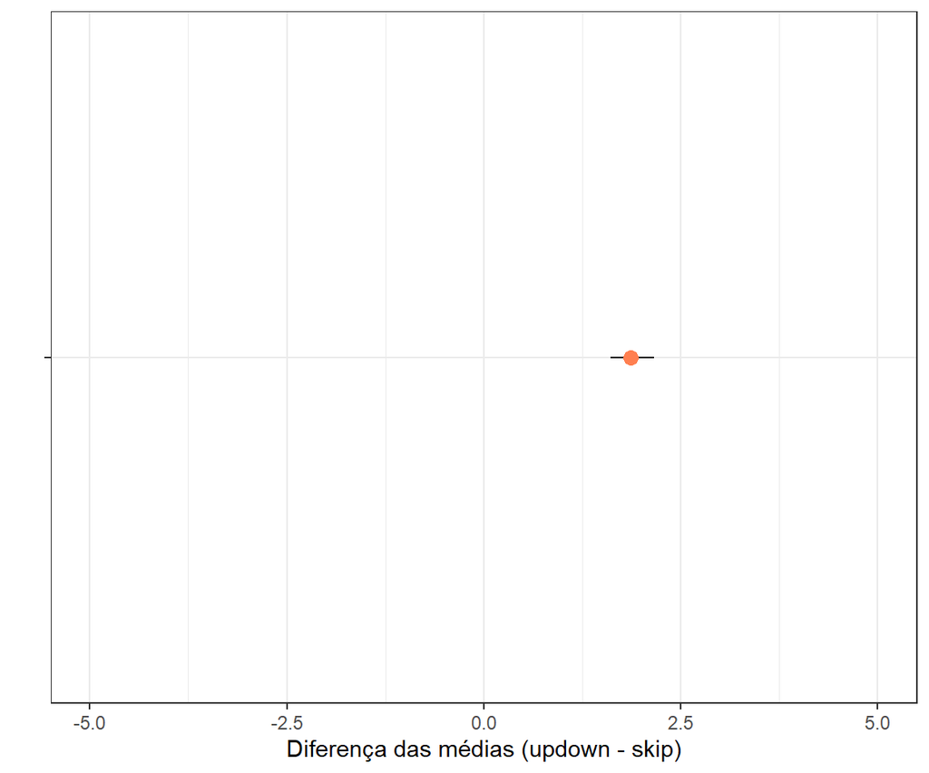

```r
ci_skip_updown %>%
  ggplot(aes(
            ymin = conf.low,
            y = statistic,
            ymax = conf.high,
            x = ""
        )) +
        geom_linerange() +
        geom_point(color = "coral", size = 3) +
        scale_y_continuous(limits = c(-5, 5)) +
        labs(x = "", y = "Diferença das médias (updown - skip)") +
        coord_flip()
```

**Com a diferença das médias de 1.86 e variação entre 1.61 e 2.15, para aumentar a satisfação dos usuários seria recomendado utilizar o up/downvoting visto que este possui um efeito relevante de médio à alto se comparado ao skip.**

### Se implementar a variante combined é a opção mais trabalhosa, em que situação você a recomendaria para implementação?

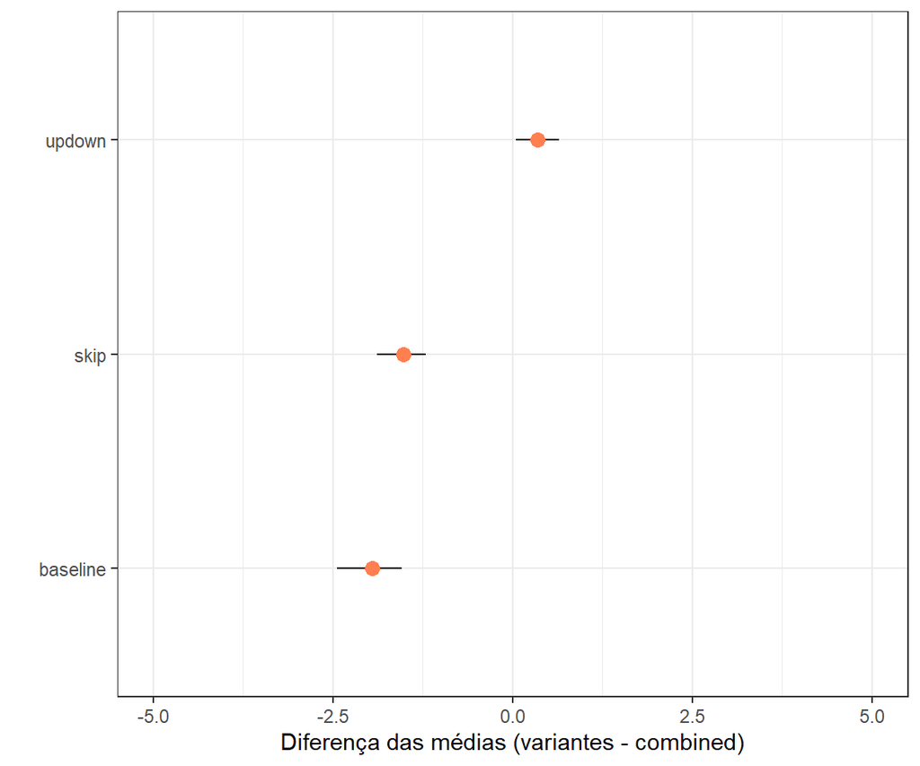

```r
cis %>%
  ggplot(aes(
            ymin = conf.low,
            y = statistic,
            ymax = conf.high,
            x = grupo
        )) +
        geom_linerange() +
        geom_point(color = "coral", size = 3) +
        scale_y_continuous(limits = c(-5, 5)) +
        labs(x = "", y = "Diferença das médias (variantes - combined)") +
        coord_flip()
```

**A opção combined seria mais recomendada a ser implementada quando se desejasse ter uma melhora relativamente significante na satisfação dos usuários se a variante anterior tivesse efeito semelhante ao baseline e ao skip, porém se a variante anterior tivesse efeito semelhante ao up/downvoting, provavelmente não valeria a pena implementá-la visto que o novo efeito seria pouco relevante.**